# Presentación Examen Final

Jorge III Altamirano Astorga (175904) Uriel Miranda Miñon (177508)  
2017/12/02

## What's Cooking

### Dataset by Yummly

### Objetivo

(Ganar la competencia de Kaggle o tener un buen lugar) Determinar en base a los ingredientes el tipo de cocina a la que pertenece un platillo.

Existen alrededor más de 6,000 ingredients en el dataset de entrenamiento (raw):

- Con 39,774 observaciones para el set de entrenamiento
- Clasificados en 20 tipos de cocinas: mexicana, francesa, griega, …

Para el set de prueba son 9,944 observaciones.

Dentro de Aprendizaje Máquina éste es un problema de Aprendizaje Supervisado y de Clasificación.

### Datos

Los datos están en formato JSON, con una lista anidada y el ID en desorden como se muestra aquí.

```r
train <- fromJSON("data/train.json")
train <- train %>% as.data.frame
train %>% head(n=4) %>% kable
```

| id | cuisine | ingredients |
| --- | --- | --- |
| 10259 | greek | romaine lettuce, black olives, grape tomatoes, garlic, pepper, purple onion, seasoning, garbanzo beans, feta cheese crumbles |
| 25693 | southern_us | plain flour, ground pepper, salt, tomatoes, ground black pepper, thyme, eggs, green tomatoes, yellow corn meal, milk, vegetable oil |
| 20130 | filipino | eggs, pepper, salt, mayonaise, cooking oil, green chilies, grilled chicken breasts, garlic powder, yellow onion, soy sauce, butter, chicken livers |
| 22213 | indian | water, vegetable oil, wheat, salt |

### Datos: Limpieza

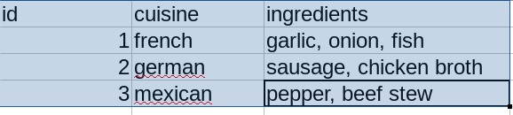

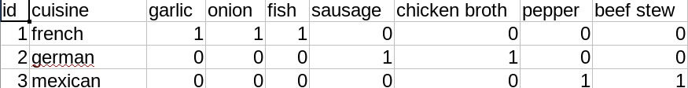

### Datos: Mucha Limpieza

- Existen ingredientes repetidos en las recetas y en esencia; incluían cosas como *minced*, *cubed*, *a taste of*, *oz*, *warm*, *hot*, *toasted*, *young*, *fresh*, …
- Algunos caracteres se repetían por acentos o similares
- Algunos ingredientes tenían marcas: *Oscar Mayer*, *Kraft*, *Land O'Lakes*, …
- Algunos contenían mayúsculas y minúsculas

```r
train$ingredients %>% unlist %>%  tolower %>%unique %>% data.frame(x=.) %>% arrange(x) %>%  head(n=10) %>% kable
```

| x |
| --- |
| ( oz.) tomato sauce |
| ( oz.) tomato paste |
| (10 oz.) frozen chopped spinach |
| (10 oz.) frozen chopped spinach, thawed and squeezed dry |
| (14 oz.) sweetened condensed milk |
| (14.5 oz.) diced tomatoes |
| (15 oz.) refried beans |
| 1% low-fat buttermilk |
| 1% low-fat chocolate milk |
| 1% low-fat cottage cheese |

### Datos: reducción de variables

- Muchos ingredientes estaban mencionados pocas veces

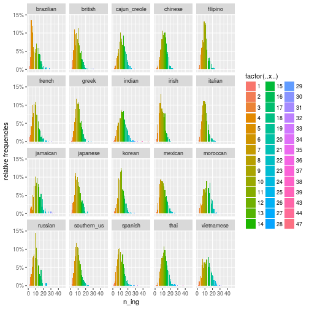

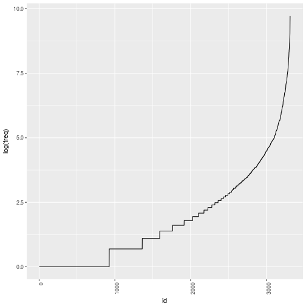

### Datos: Por tipo cocina

Antes de aplicar cualquier modelo empezamos a intuir que podría costarle más trabajo aprender ciertos tipos que otros. Resultó cierto.

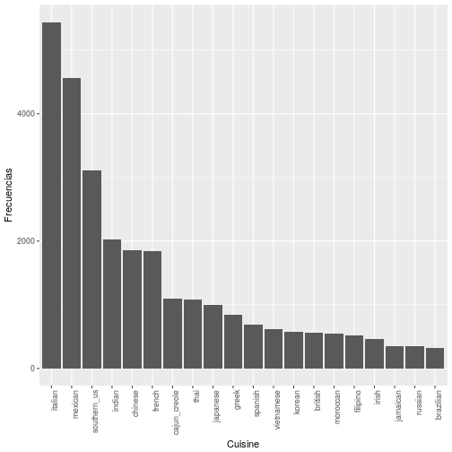

### Métodos

**#2 Bosques Aleatorios**

**#3 Árboles:**

| correctos | train | val |
| --- | --- | --- |
| FALSE | 8762 | 4096 |
| TRUE | 19079 | 7837 |

| correctos | train | val |
| --- | --- | --- |
| FALSE | 2681 | 3621 |
| TRUE | 25160 | 8312 |

[output not shown]

### SVM

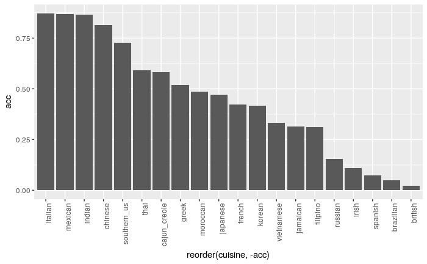

### RandomForest

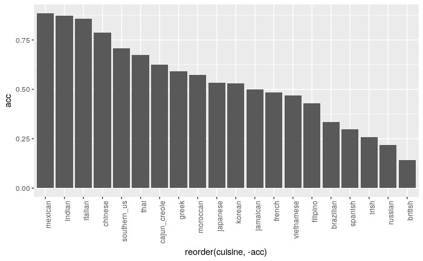

### Conclusiones

- Muchas de los datasets eran muy grandes, incluso este requería muchos recursos
- Los datos y su limpieza muchas veces son una buena parte del trabajo
- Se requiere de tener conocimiento del tema para poder aprovechar mejor esos datos
- Nuestra herramienta más útil para la limpieza fueron los Regular Expressions

### Bibliografía

- [Aprendizaje Máquina - Luis Felipe González](https://felipegonzalez.github.io/aprendizaje-maquina-2017/)
- [kaggle.com/What's cooking](https://www.kaggle.com/c/whats-cooking/data)
- [R SVM @R-Project's Cran](https://cran.r-project.org/web/packages/e1071/vignettes/svmdoc.pdf)